# Текстовой редактор vi

Лабораторная работа No 8

Козлова Нонна

Российский университет дружбы народов, Москва, Россия

НБИбд-04-22

## Цели и задачи

Познакомиться с операционной системой Linux. Получить практические навыки рабо- ты с редактором vi, установленным по умолчанию практически во всех дистрибутивах

## Ход работы

1. Создаю каталог с именем ~/work/os/lab06, перехожу в созданный каталог.

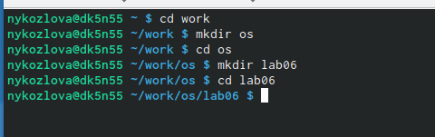

Пользуюсь командой mkdir

2. Вызываю vi и создаю файл hello.sh

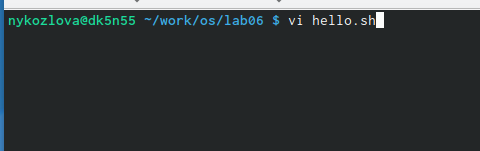

Пользуюсь командой vi

3. Нажимаю клавишу i и ввожу предложеный текст

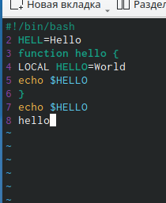

Использую клавишу i для режима вставки

4. Нажмимаю клавишу Esc для перехода в командный режим после завершения ввода текста

Использую клавишу esc

5. Нажимаю : для перехода в режим последней строки

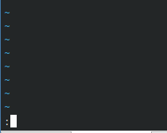

внизу экрана появляется приглашение в виде двоеточия.

6. Нажимаю w (записать) и q (выйти), а затем нажимаю клавишу Enter для сохранения текста и завершения работы

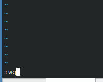

Получается :wq

7. Делаю файл исполняемым

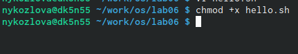

Пользуюсь командой chmod

8. Вызываю vi на редактирование файла

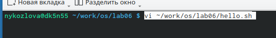

Пользуюсь командой vi

9. Устанавливаю курсор в конец слова HELL второй строки

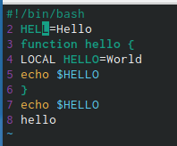

Пользуюсь клавишами, а не мышкой

10. Перехожу в режим вставки и заменяю на HELLO. Нажимаю Esc для возврата в команд- ный режим .

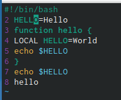

Пользуюсь клавишей i

11. Устанавливаю курсор на четвертую строку и стираю слово LOCAL.

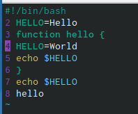

Пользуюсь клавишей i

12. Перехожу в режим вставки и набираю следующий текст: local, нажимаю Esc для возврата в командный режим.

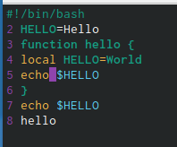

Пользуюсь клавишей i

13. Устанавливаю курсор на последней строке файла. Вставляю после неё строку, содержащую следующий текст: echo $HELLO.

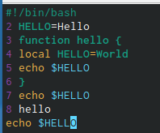

Пользуюсь клавишей i

14. Удаляю последнюю строку

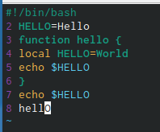

Пользуюсь клавишей i

15. Отменяю последнюю команду

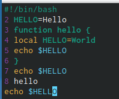

Пользуюсь клавишей u

16. Ввожу символ : для перехода в режим последней строки

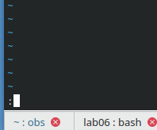

В конце строки появился этот символ

## Итоговый слайд

В ходе лабораторной работы я познакомилась с операционной системой Linux. Получила практические навыки работы с редактором vi, установленным по умолчанию практически во всех дистрибутивах